# R JAGS First Look

Simon Thornewill von Essen

12/20/2019

In this R Markdown, we will be trying to implement the same example as in the `random-walk_example.Rmd`, except using the R JAGS package.

## Specify The Model

After we have imported the `rjags` package, we need to specifiy the heirarchical archetecture of the model.

```r
mod_string <- "model {
  for(i in 1:n){
    y[i] ~ dnorm(mu, 1.0/sig2)
  }

  mu ~ dt(0.0, 1.0/1.0, 1)
  sig2 <- 1.0
}"
```

Note that the model needed to be formatted as a string type. After that we can say that distribution our data follows and set the appropriate priors for our model.

## Set-up The Model

Now that our model has been specified, we should specify our data:

```r
set.seed(42)
y <- c(1.2, 1.4, -0.5, 0.3, 0.9, 2.3, 1.0, 0.1, 1.3, 1.9)
n <- length(y)
```

Note that there are some variables that are in the model from the previous section, but that JAGS won’t be able to handle. We will need to specifcy these things for it.

Also, it won’t know what the parameters are, we also will specify this.

```r
data_jags <- list(y=y, n=n)
params <- c("mu")
```

We also need to set our initial values for each parameter that we specified.

```r
inits <- function(){
  inits <- list("mu"=0.0)
}
```

Finally, we need to put everything together.

```r
mod <- jags.model(textConnection(mod_string),
                  data = data_jags,
                  inits = inits)
```

Great! Now our model is set up and we can go to the next step!

## Run MCMC Sampler

Now that our algorithm has been set up, let’s sample from the posterior distribution.

```r
# Specify burn in interval
update(mod, 500)

# Sample from posterior
mod_sim <- coda.samples(model=mod,
                        variable.names = params,
                        n.iter=1000)
```

## Post Processing

Now that we have sampled from the posterior distribution, we can have a look at our results.

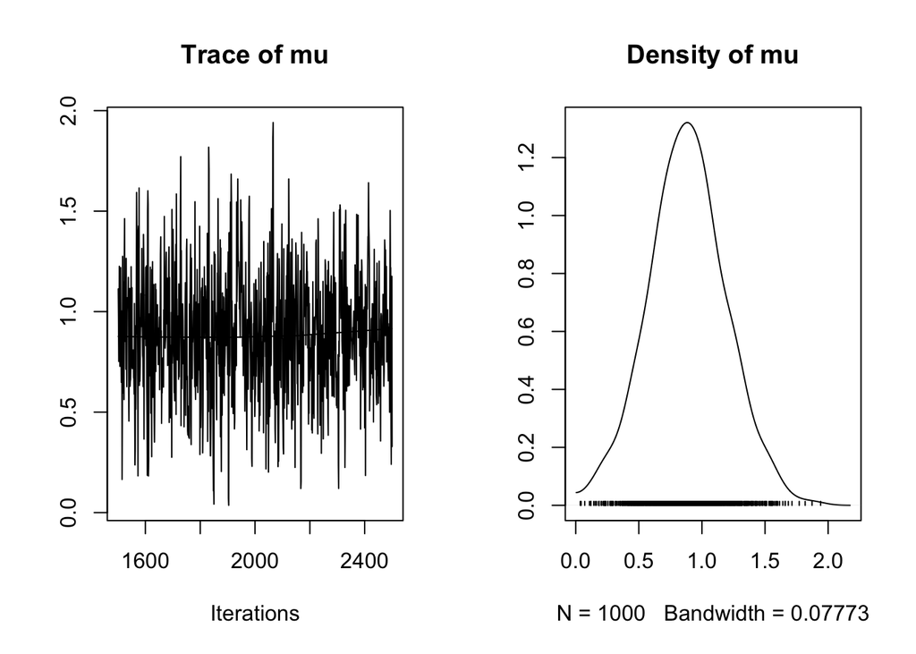

```r
plot(mod_sim)
```

Using the `plot` functionm we can see the trace of our parameter. It looks like it has converged nicely. We also get a density estimation for what we believe the value of mu to be. Which is quite practical.

```r
summary(mod_sim)
```

```
##
## Iterations = 1501:2500
## Thinning interval = 1
## Number of chains = 1
## Sample size per chain = 1000
##
## 1. Empirical mean and standard deviation for each variable,
##    plus standard error of the mean:
##
##           Mean             SD       Naive SE Time-series SE
##       0.885231       0.306917       0.009706       0.012610
##
## 2. Quantiles for each variable:
##
##   2.5%    25%    50%    75%  97.5%
## 0.2706 0.6820 0.8782 1.0732 1.5085
```

We can also use the `summary` function to get some more of an idea about what part of our model we are using, statistics about our parameters and stuff like that.